# Assignment_3

### Q1

Code used to Generate the barplot

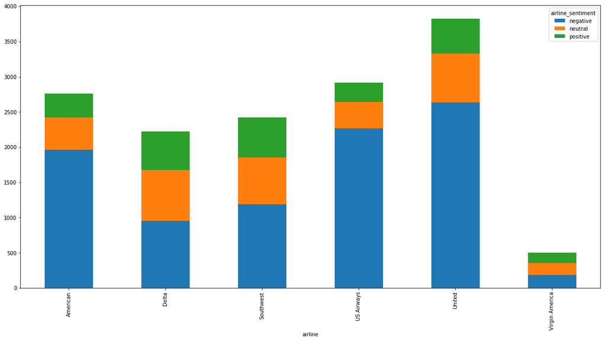

```python
import pandas as pd
import matplotlib.pyplot as plt
import os
from wordcloud import WordCloud
import warnings
warnings.filterwarnings('ignore')

df = pd.read_csv("Tweets.csv")

df2 = df.groupby(['airline', 'airline_sentiment'])['airline'].count().unstack('airline_sentiment').fillna(0)
df2.plot(kind='bar', stacked=True, figsize=[20,10])
```

### In this barchart we can look the sentiments of reviews expressed by the passengers for 6 different airline carriers, on the Y-AXIS we have the number of tweets and on the X-AXIS we have the various airline carriers. Each bar graph for airline is broken down into 'Positive', 'Negative' and 'Neutral' tweets.

### Q2

Code used to generate the plot for studying various reasons of negative feedback.

```
array([<matplotlib.axes._subplots.AxesSubplot object at 0x000002C999AA1320>],
      dtype=object)
```

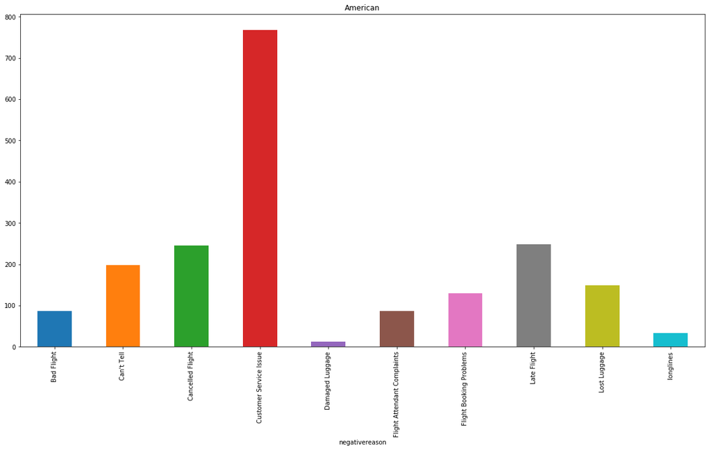

```python
import plotly.plotly as py
import plotly.tools as tls

import matplotlib.pyplot as plt

df2 = df.groupby([ 'negativereason','airline'])['negativereason'].count().unstack('negativereason').fillna(0)
df2.iloc[0].plot(kind='bar', figsize=[20,10], subplots=True)
```

### Here we can see the distribution of feedback for negative reasons, for American Airlines, from the graph it looks the airline needs to work on their customer service department as it is biggest cause of concern for passengers.

```
array([<matplotlib.axes._subplots.AxesSubplot object at 0x00000271593C0320>],
      dtype=object)
```

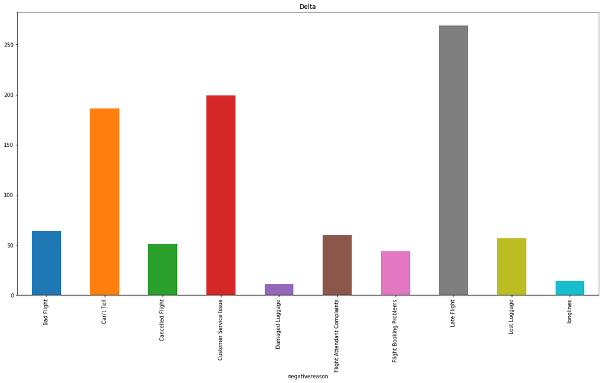

```python
#Plot for Delta Airlines
df2.iloc[1].plot(kind='bar', figsize=[20,10], subplots=True)
```

### Most common cause of dissatisfaction for Delta: Late flights

```
array([<matplotlib.axes._subplots.AxesSubplot object at 0x0000027162318160>],
      dtype=object)
```

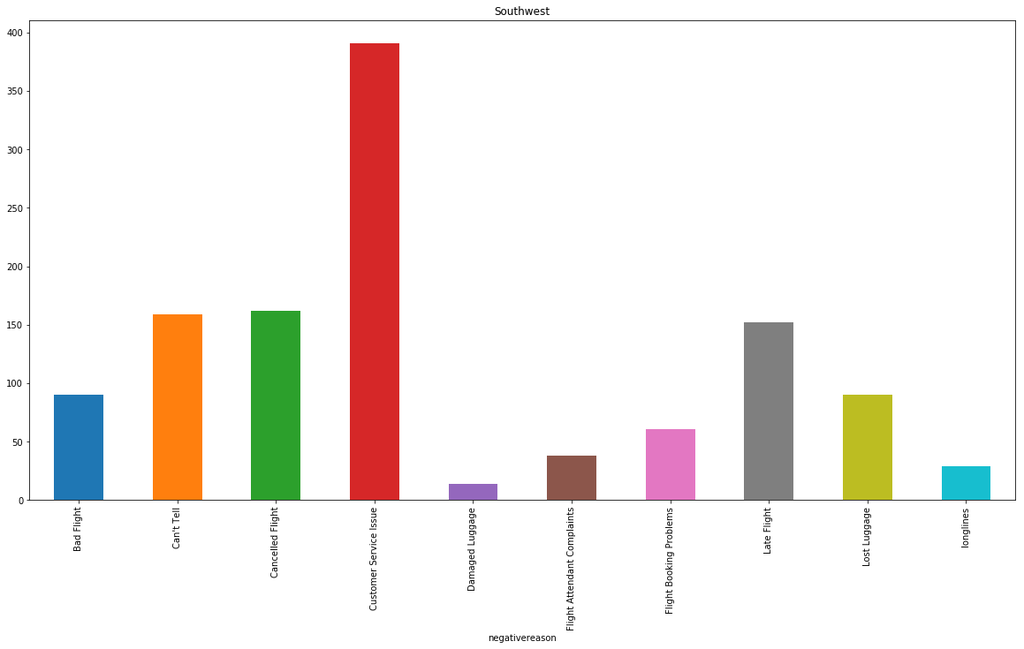

```python
##Plot for Southwest Airlines
df2.iloc[2].plot(kind='bar', figsize=[20,10], subplots=True)
```

### Most common cause of dissatisfaction for Southwest: Customer service

```
array([<matplotlib.axes._subplots.AxesSubplot object at 0x000002837DDCBE48>],
      dtype=object)
```

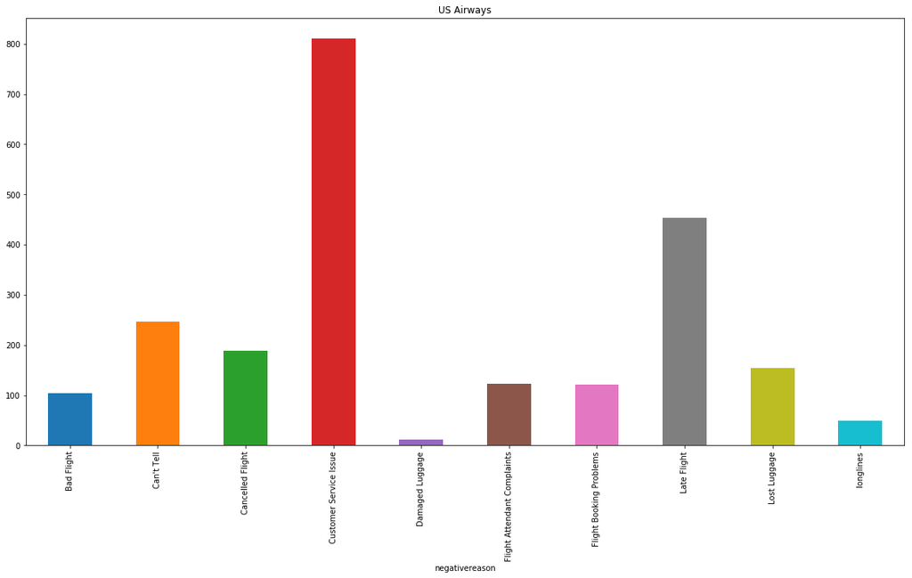

```python
#Plot for US Airways
df2.iloc[3].plot(kind='bar', figsize=[20,10], subplots=True)
```

### Most common cause of dissatisfaction for US aiways: Customer service

```
array([<matplotlib.axes._subplots.AxesSubplot object at 0x000002837DF2B550>],
      dtype=object)
```

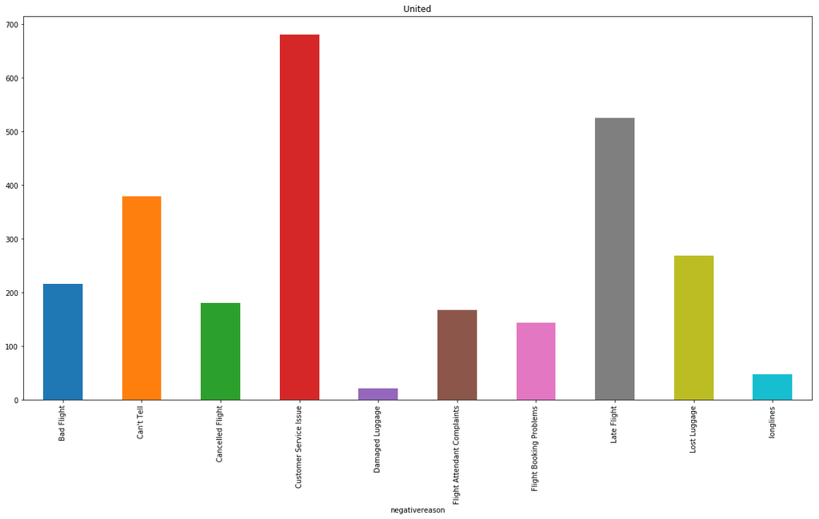

```python
#Plot for United airlines
df2.iloc[4].plot(kind='bar', figsize=[20,10], subplots=True)
```

### Most common cause of dissatisfaction for United: Customer service

```
array([<matplotlib.axes._subplots.AxesSubplot object at 0x000002837DFACBA8>],
      dtype=object)
```

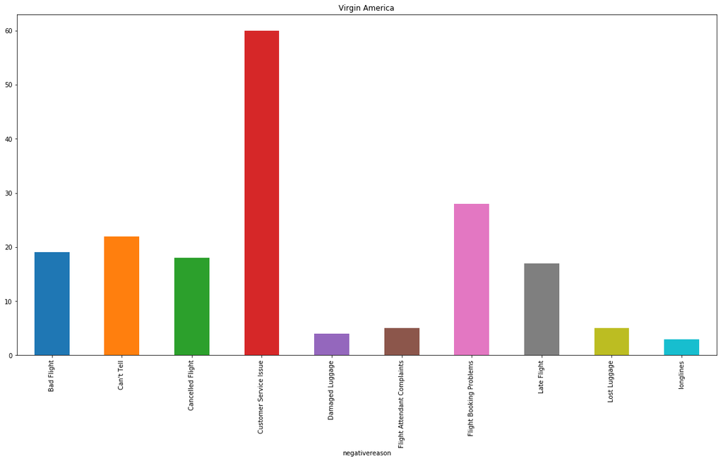

```python
#Plot for Virgin american airlines
df2.iloc[5].plot(kind='bar', figsize=[20,10], subplots=True)
```

### Most common cause of dissatisfaction for Virgin: Customer service

[output not shown]

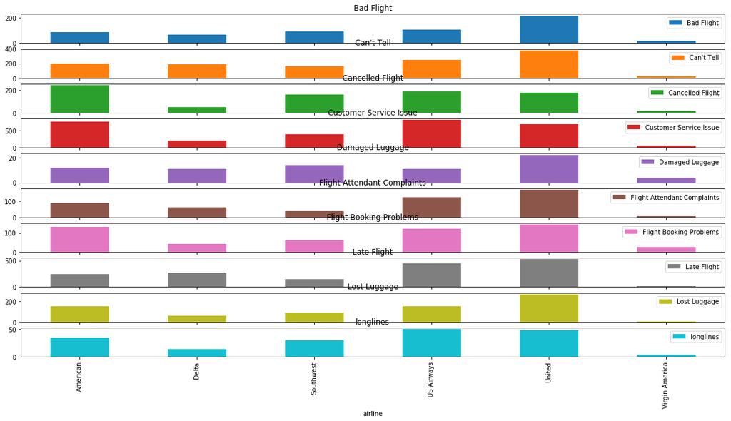

```python
#All airlines together
df2.plot(kind='bar', figsize=[20,10], subplots=True)
```

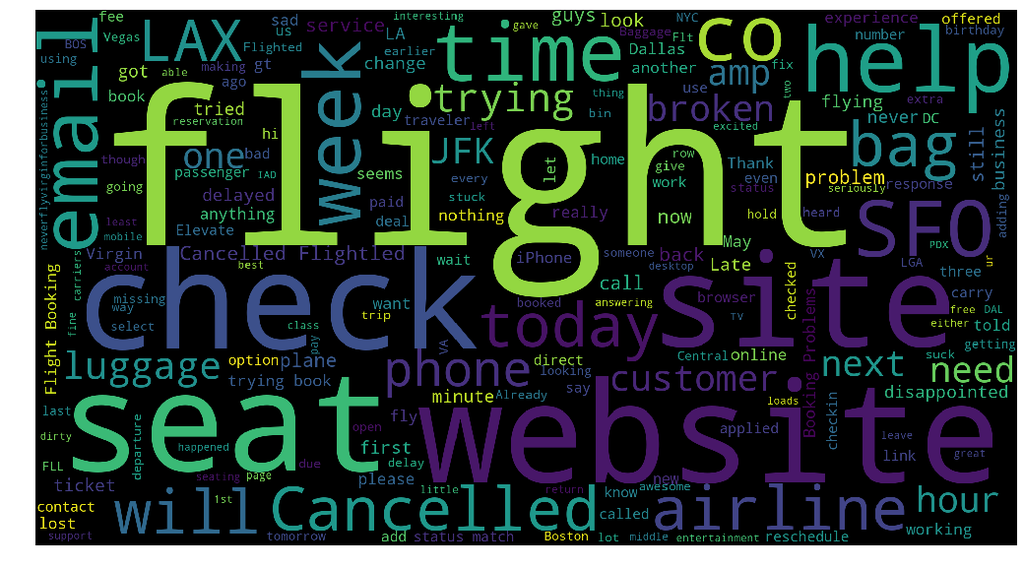

```python
text = open('Virgin_neg.txt','r', encoding="UTF8").read()

# Generate a word cloud object and plot it on the x and y axis
wordcloud = WordCloud(width=1980,height=1080).generate(text)

plt.figure( figsize=(20,10) )
plt.imshow(wordcloud)

#Turn off the axis. Otherwise you will see a bunch of extra numbers around the word cloud
plt.axis("off")

#Show the word cloud
plt.show()
```

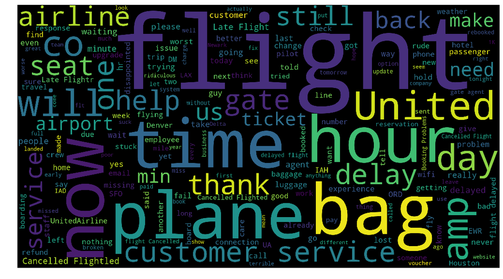

```python
text_united = open('United_neg.txt','r', encoding="UTF8").read()

# Generate a word cloud object and plot it on the x and y axis
wordcloud = WordCloud(width=1980,height=1080).generate(text_united)

plt.figure( figsize=(20,10) )
plt.imshow(wordcloud)

#Turn off the axis. Otherwise you will see a bunch of extra numbers around the word cloud
plt.axis("off")

#Show the word cloud
plt.show()
```

### Above is wordcloud for United: They seem to have issues with delys, missing bags and customer service

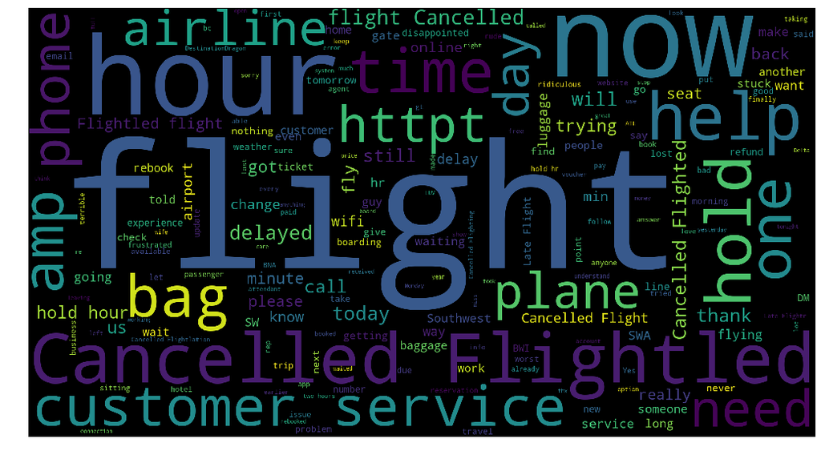

```python
text_southern = open('Southern_air.txt','r', encoding="UTF8").read()

# Generate a word cloud object and plot it on the x and y axis
wordcloud = WordCloud(width=1980,height=1080).generate(text_southern)

plt.figure( figsize=(20,10) )
plt.imshow(wordcloud)

#Turn off the axis. Otherwise you will see a bunch of extra numbers around the word cloud
plt.axis("off")

#Show the word cloud
plt.show()
```

### Above is wordcloud for Southern_air: They seem to have issues with cancelled flights

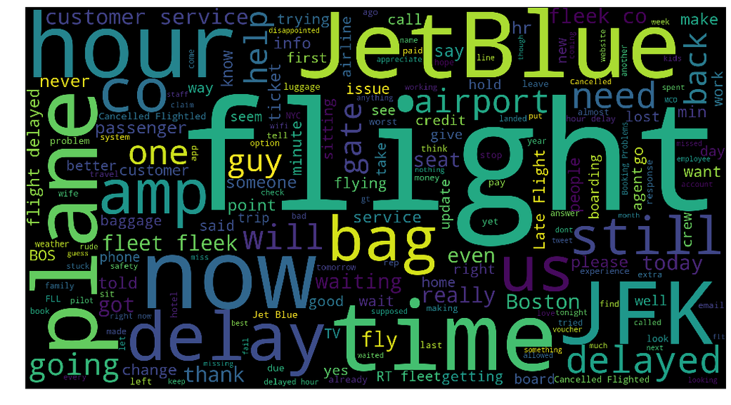

```python
text_jet = open('Jet_blue.txt','r', encoding="UTF8").read()

# Generate a word cloud object and plot it on the x and y axis
wordcloud = WordCloud(width=1980,height=1080).generate(text_jet)

plt.figure( figsize=(20,10) )
plt.imshow(wordcloud)

#Turn off the axis. Otherwise you will see a bunch of extra numbers around the word cloud
plt.axis("off")

#Show the word cloud
plt.show()
```

### Above is wordcloud for Jetblue: They seem to have issues with delayed flights

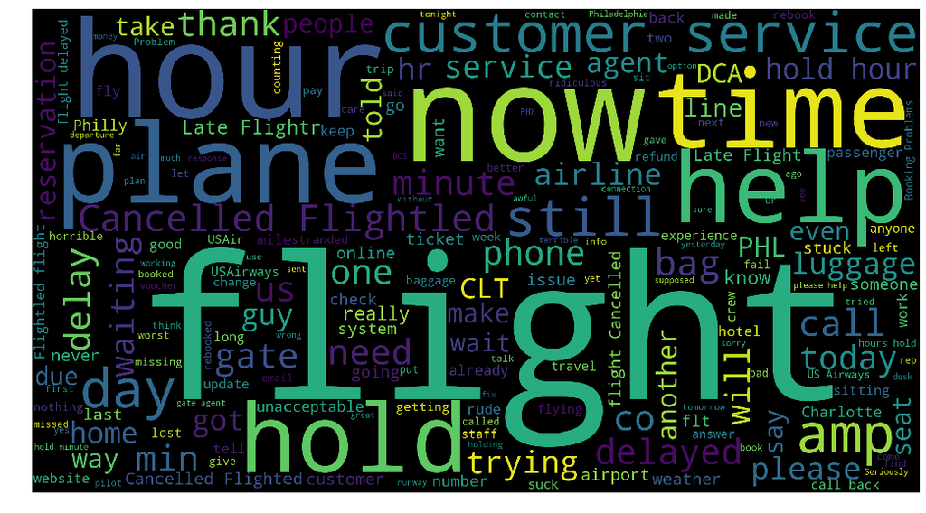

```python
text_us = open('Us_air.txt','r', encoding="UTF8").read()

# Generate a word cloud object and plot it on the x and y axis
wordcloud = WordCloud(width=1980,height=1080).generate(text_us)

plt.figure( figsize=(20,10) )
plt.imshow(wordcloud)

#Turn off the axis. Otherwise you will see a bunch of extra numbers around the word cloud
plt.axis("off")

#Show the word cloud
plt.show()
```

### Above is wordcloud for US airways: They seem to have issues with customer service

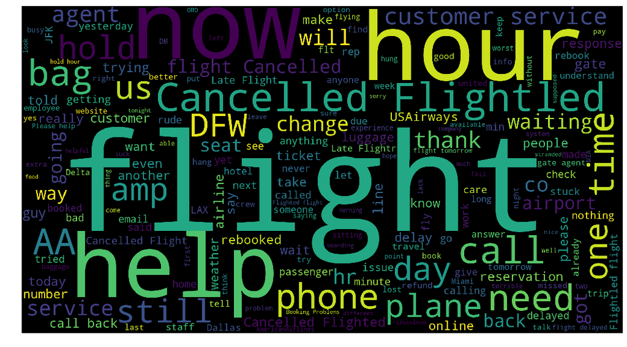

```python
text_american = open('American_can.txt','r', encoding="UTF8").read()

# Generate a word cloud object and plot it on the x and y axis
wordcloud = WordCloud(width=1980,height=1080).generate(text_american)

plt.figure( figsize=(20,10) )
plt.imshow(wordcloud)

#Turn off the axis. Otherwise you will see a bunch of extra numbers around the word cloud
plt.axis("off")

#Show the word cloud
plt.show()
```

```python
### Above is wordcloud for American airlines: They seem to have issues with cancelled flights
```

```python
#LDA

import spacy
spacy.load('en')
from spacy.lang.en import English
parser = English()
def tokenize(text):
    lda_tokens = []
    tokens = parser(text)
    for token in tokens:
        if token.orth_.isspace():
            continue
        elif token.like_url:
            lda_tokens.append('URL')
        elif token.orth_.startswith('@'):
            lda_tokens.append('SCREEN_NAME')
        else:
            lda_tokens.append(token.lower_)
    return lda_tokens
```

```python
import nltk
nltk.download('wordnet')
from nltk.corpus import wordnet as wn
def get_lemma(word):
    lemma = wn.morphy(word)
    if lemma is None:
        return word
    else:
        return lemma

from nltk.stem.wordnet import WordNetLemmatizer
def get_lemma2(word):
    return WordNetLemmatizer().lemmatize(word)
```

```python
nltk.download('stopwords')
en_stop = set(nltk.corpus.stopwords.words('english'))
```

```python
def prepare_text_for_lda(text):
    tokens = tokenize(text)
    tokens = [token for token in tokens if len(token) > 4]
    tokens = [token for token in tokens if token not in en_stop]
    tokens = [get_lemma(token) for token in tokens]
    return tokens
```

```python
import random
import pandas as pd
text_data = []
df = pd.read_csv("Tweets.csv")
for line in df.text:
    tokens = prepare_text_for_lda(line)
    if random.random() > .99:
        print(tokens)
    text_data.append(tokens)
```

```
['SCREEN_NAME', 'pretty', 'graphics', 'better', 'minimal', 'iconography']
['.@virginamerica', 'great', 'return', 'call', 'could', 'myvxexperience']
['SCREEN_NAME', 'flying']
['SCREEN_NAME', 'complete', 'doubt', 'vacation', 'responsibility']
['SCREEN_NAME', 'plane', 'delay', 'baggage', 'loading', 'issue']
['SCREEN_NAME', 'thank', 'follow', 'otherwise']
['SCREEN_NAME', 'assign', 'without', 'pay']
['SCREEN_NAME', 'miss', 'flight', 'flight', 'minutes', 'would', 'watch']
['SCREEN_NAME', 'customer', 'service']
['SCREEN_NAME', 'years', 'lose', 'customer']
['SCREEN_NAME', 'frustrate', 'flying', 'experience', 'continuous', 'dunno', 'leave', 'today', 'dunno']
['SCREEN_NAME', 'seriously', 'delay', 'copilot', 'hours', 'flying', 'raleigh', 'disappoint']
['SCREEN_NAME', 'calling', 'tomorrow']
['SCREEN_NAME', 'direct', 'message', 'follow', 'luggage', 'please']
['SCREEN_NAME', 'incredibly', 'unfriendly', 'ground', 'staff', 'false', 'promise', 'twitter', 'SCREEN_NAME']
['SCREEN_NAME', 'skilled', 'staff', 'inadequate', 'system', 'delete', 'return', 'houston', 'norway', 'shoulder', 'shrug']
['SCREEN_NAME', 'would', 'think', 'would', 'clean', 'ramp', 'stick', 'newark', 'would', 'never', 'happen', 'SCREEN_NAME']
['SCREEN_NAME', 'compensation', 'upgrade', 'higher', 'class', 'reschedule', 'flight', 'today', 'appreciate', 'though']
['SCREEN_NAME', 'ready', 'agent', 'going']
['SCREEN_NAME', 'flight', 'seats', 'morning']
['SCREEN_NAME', 'flight', 'delay', 'another', 'transit', 'extremely', 'unlikely']
['SCREEN_NAME', 'tonight', 'flintstone', 'happy', 'upgrade', 'class']
['SCREEN_NAME', 'sitting', 'runway', 'hours', 'ridiculous']
['SCREEN_NAME', 'great', 'lose', 'direct', 'flight', 'manage']
['SCREEN_NAME', 'flight', 'cancel', 'flightled', 'mechanical', 'issue', 'weather']
['SCREEN_NAME', 'charge', 'people', 'freak', 'flight']
['SCREEN_NAME', 'unbelievably', 'disappoint', 'delay', 'delay', 'mess']
['SCREEN_NAME', 'digging', 'mileage', 'earn', 'would', 'mile', 'change', 'award', 'ticket', 'price']
['SCREEN_NAME', 'surprise', 'never', 'experience', 'anything', 'number']
['SCREEN_NAME', 'details', 'flight', 'recording', 'repeat', 'person']
['SCREEN_NAME', 'cancel', 'flightled', '5102newflight', 'upset', 'cancel', 'flight', 'could', 'rent', 'would', 'honest']
['SCREEN_NAME', 'spite', 'flight', 'delay', 'great', 'customer', 'service', 'provide', 'janet', 'baggage', 'employee', 'karen', 'wonderful', 'employee', 'unite']
['SCREEN_NAME', 'agent', 'clifton', 'father', 'dying', 'need', 'handbag', 'cabin', 'nothing', 'shameful']
['SCREEN_NAME', 'thanks', 'form', 'submit', 'bet', 'someone', 'would', 'honest', 'enough', 'though']
['SCREEN_NAME', 'partner', 'book', 'individual', 'reservation', 'flight', 'silver', 'share', 'premier', 'privilege', 'somehow']
['SCREEN_NAME', 'still', 'sitting', 'waiting', 'plane', 'hours', 'waste']
['SCREEN_NAME', 'airline', 'person', 'working', 'special', 'services']
['SCREEN_NAME', 'thank', 'address']
['SCREEN_NAME', 'SCREEN_NAME', 'really', 'crash', 'sayin']
['SCREEN_NAME', 'happen', 'unite', 'pilot', 'always', 'america', 'treat', 'customer', 'better', 'employee']
```

[output cut: 89 more lines]

```
['SCREEN_NAME', 'tjycqh', 'airport', 'since', 'schedule', 'ashamed', 'disgust']
['SCREEN_NAME', 'start', 'water', 'SCREEN_NAME']
['SCREEN_NAME', 'thanks', 'charge', 'anything']
['SCREEN_NAME', 'waiting', 'three', 'hours', 'someone', 'rebook', 'flight', 'weather', 'service', 'actually']
['SCREEN_NAME', 'thank', 'response', 'try', 'number', 'airway', 'number']
['SCREEN_NAME', 'flight', 'cancel', 'flightled', 'answer', 'flight', 'please']
['SCREEN_NAME', 'awesome', 'customer', 'service', 'sneak', 'cookie']
['SCREEN_NAME', 'friend', 'flight', 'aa362', 'dfw&gt;&gt;mke', 'cancel', 'flight', 'weather', 'option']
['SCREEN_NAME', 'flight', 'matter', 'flight', 'cancel', 'flight', 'morning', 'since']
['SCREEN_NAME', 'sitting', 'flight', 'sabre', 'backup', 'place', 'sabre', 'fix']
['SCREEN_NAME', 'please', 'steal', 'incompetent', 'employee', 'abcnews', 'msnbc', 'photography']
['SCREEN_NAME', 'SCREEN_NAME', 'woody', 'making', 'worse', 'understaffing', 'rudeness', 'rookie', 'mistake']
['SCREEN_NAME', 'appreciate', 'update', 'appreciate', 'pilot', 'effort', 'explain', 'accurate', 'authoritative', 'comms', 'vital']
['SCREEN_NAME', 'overweight', 'dozen', 'passenger', 'luggage', 'seriously']
['SCREEN_NAME', 'flight', 'cancel', 'flightled', 'leaving', 'tomorrow', 'morning', 'rebooked', 'tuesday', 'night', 'flight', 'arrive', 'monday']
```

```python
from gensim import corpora
dictionary = corpora.Dictionary(text_data)
corpus = [dictionary.doc2bow(text) for text in text_data]

import pickle
pickle.dump(corpus, open('corpus.pkl', 'wb'))
dictionary.save('dictionary.gensim')
```

```python
import gensim
NUM_TOPICS = 7
ldamodel = gensim.models.ldamodel.LdaModel(corpus, num_topics = NUM_TOPICS, id2word=dictionary, passes=15)
ldamodel.save('model5.gensim')
topics = ldamodel.print_topics(num_words=4)
for topic in topics:
    print(topic)
```

```
(0, '0.145*"SCREEN_NAME" + 0.119*"flight" + 0.048*"cancel" + 0.024*"flightled"')
(1, '0.118*"SCREEN_NAME" + 0.044*"flight" + 0.025*"sitting" + 0.019*"plane"')
(2, '0.147*"SCREEN_NAME" + 0.064*"service" + 0.063*"customer" + 0.016*"email"')
(3, '0.150*"SCREEN_NAME" + 0.059*"flight" + 0.055*"delay" + 0.035*"plane"')
(4, '0.211*"SCREEN_NAME" + 0.059*"thanks" + 0.028*"thank" + 0.023*"flight"')
(5, '0.151*"SCREEN_NAME" + 0.032*"please" + 0.024*"really" + 0.017*"luggage"')
(6, '0.147*"SCREEN_NAME" + 0.018*"american" + 0.013*"ticket" + 0.012*"system"')
```

```python
import pyLDAvis.gensim

pyLDAvis.enable_notebook()
panel = pyLDAvis.gensim.prepare(ldamodel, corpus, dictionary)
pyLDAvis.display(panel)
```

[interactive chart not shown]

### In this topic modelling I have chosen 7 topics to reflect all the possible negative reasons.

```python
Additional analysis, let's look at the number of '@' in the tweets to indentify a pattern.
```

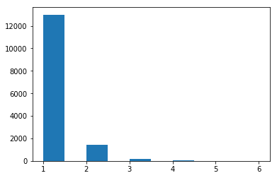

```python
list =[]
for i in range(14640):
    list.append(df['text'][i].count('@'))

newdat=pd.DataFrame(list)

newdat.columns=["at_count"]

newdat.head(5)

df_3=pd.concat([df,newdat],axis=1)

plt.hist(df_3["at_count"])
```

### Here we can see that the number of mentions i.e usage of '@' symbols follows a poisson distribution

Let's look at the relationship b/w length of the tweet and sentiment, first we create a new column called tweet_length append it to the data frame and then we shall look at the counts of tweets with their lengths

```python
#Tweet length and sentiment
list2 =[]
for i in range(14640):
    list2.append(len(df['text'][i]))

newdat2=pd.DataFrame(list2)

newdat2.columns=["tweet_length"]

df_4=pd.concat([df,newdat2],axis=1)

# df_4.head(10)
```

```python
df_new = df_4.groupby(['tweet_length', 'airline_sentiment'])['airline_sentiment'].count()
# df2.plot(kind='bar', stacked=True, figsize=[20,10])

df_new.head(10)
```

```
tweet_length  airline_sentiment
12            negative             1
              neutral              5
              positive             2
13            negative             1
              neutral              2
              positive             1
14            negative             2
              neutral              7
              positive             5
15            negative             1
Name: airline_sentiment, dtype: int64
```

```python
# postive = pd.read_csv('postive_plots.txt', sep='\t',header=None)
# # df_new.plot(kind='bar', stacked=True, figsize=[20,10])
# postive.plot(kind='line', figsize=[20,10])


import pandas as pd
import numpy as np
import matplotlib.pylab as plt
%matplotlib inline
import seaborn as sns
plot = pd.read_csv('plotfile.txt', sep='\t')

plot.columns = ['Number','Sentiment','Value']

plot.groupby(['Sentiment']).groups.keys()
plot1 = plot.loc[plot['Sentiment'] == 'negative']
plot2 = plot.loc[plot['Sentiment'] == 'positive']
plot3 = plot.loc[plot['Sentiment'] == 'neutral']
```

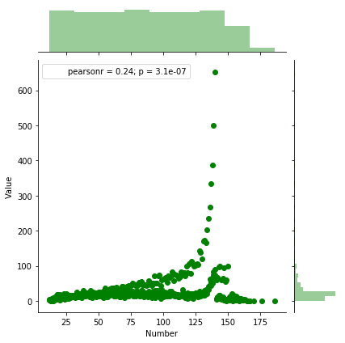

```python
sns.jointplot(x='Number', y='Value', data=plot, color='g')
```

In this plot we can see that the first curve, (negative sentiments) is much more frequently associated with longer tweets as compared to positve/neutral

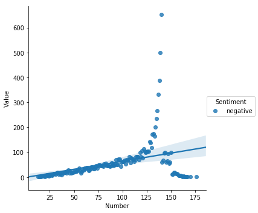

```python
sns.lmplot(x='Number', y='Value', data=plot1,
           fit_reg=True,
           hue='Sentiment')
```

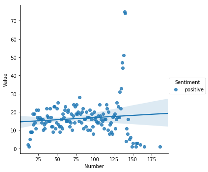

```python
sns.lmplot(x='Number', y='Value', data=plot2,
           fit_reg=True,
           hue='Sentiment')
```

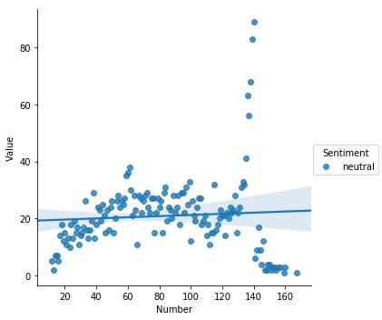

```python
sns.lmplot(x='Number', y='Value', data=plot3,
           fit_reg=True,
           hue='Sentiment')
```